# Example analysis of transaction fraud data (KYC practice - Aidan Peruch)

# Hypothesis testing

Now lets explore our features and propose some hypotheses to test. We’ll start with transaction amount.

We plot a frequency histogram of the transaction amount, scaled by $log_{10}$ since the transaction amounts are large and vary a lot.

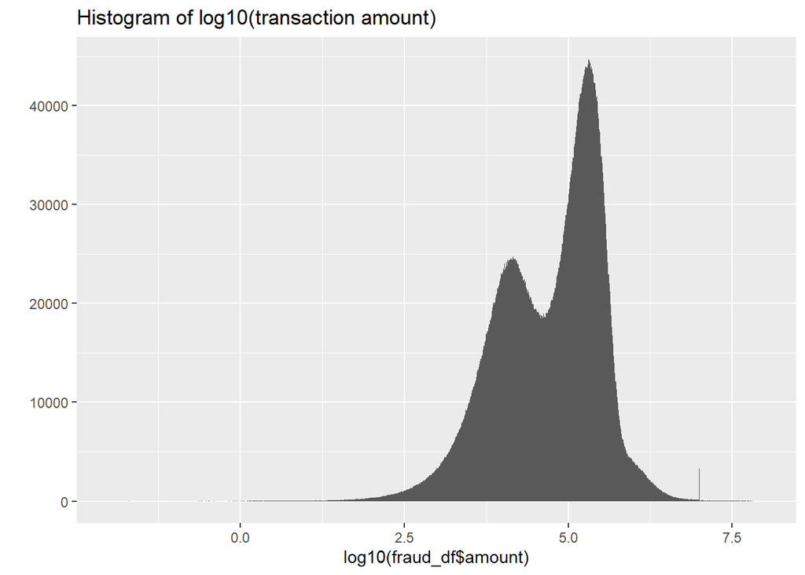

```r
qplot(log10(fraud_df$amount), bins = 1000) + labs(title = "Histogram of log10(transaction amount)")
```

From the plot this distribution appears to be bi-modal, indicating that we may have two distinct groups of data that are normally distributed.

We maybe be able to predict a fraudulent transaction by its variance from the mean of these two distributions.

Further hypothesis testing is necessary.

# Modelling

Since we have a combination of numerical and categorical variables it would be appropriate to use decision tree to model the data. We’ll drop step, name, isFlaggedFraud and leave the data unscaled for the sake of simplicity and interpretability.

```r
library(rpart)
library(caret)
```

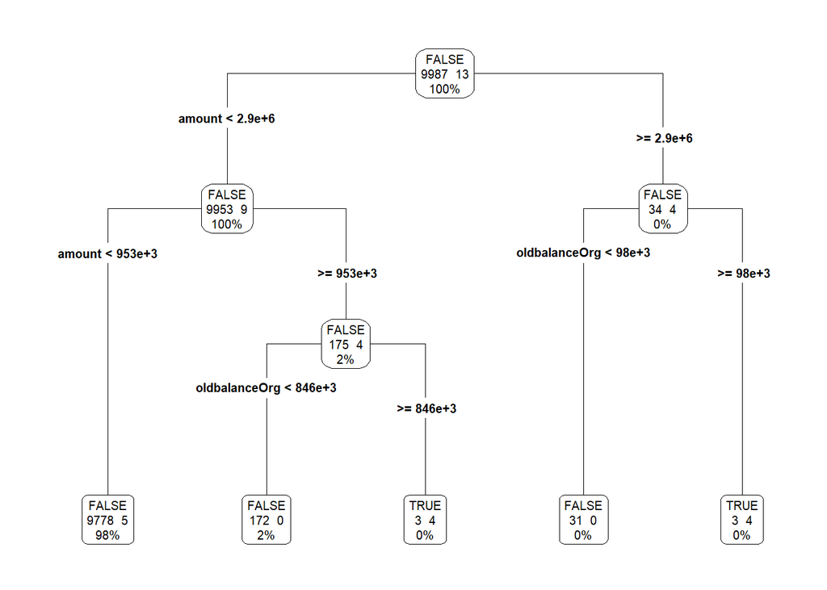

```r
library(rpart.plot)

fraud_df_tree <- fraud_df_sample %>%
        #mutate_at(c("amount", "oldbalanceOrg", "oldbalanceDest", "newbalanceDest", "newbalanceOrig"), scale) %>%
        mutate_at(c("type", "isFraud"), as.factor) %>%
        select(-step, -nameOrig, -nameDest, -isFlaggedFraud) %>% na.omit()


tree.isFraud <- rpart(isFraud~. , data=fraud_df_tree)

prp(tree.isFraud, type = 4, extra = 101, leaf.round = 1, fallen.leaves = TRUE,
    varlen = 0, tweak = 0.8)
```

The initial results using a simple decision tree with limited categorical variables and 10000 samples could greatly be improved, but there is some recognition within the model which is a promising start. Further work is needed to assess model accuracy (calculate type 1 and type 2, precision, recall). Accuracy can be improved by using more examples, including more categorical variables and model aggregation methods (random forests, boosting, bagging)